# Chapter 4 - EDA with TEUI

**How do I add more individual features or map units to same graph?** Within the Add Series pane, simply select a new feature source (if desired), map unit, feature, or raster source. Click Set Graph and the new feature or map unit will be added to the graph and the legend in a new color.

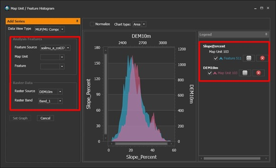

R GUI image

**Can I add multiple axes to the graph? For example, a graph of elevation and percent slope?**  
To add another axis to your graph window, simply select the feature source, a map unit if desired, or a feature if desired, but select a new raster data source. You will notice in the graph legend map units and features are separated by the raster layer.

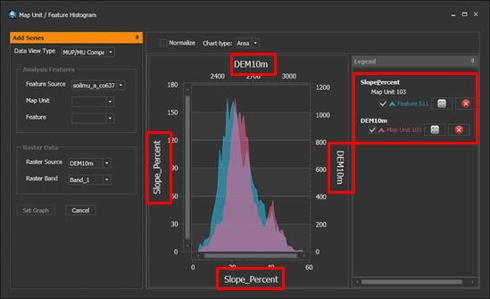

R GUI image

**Is there a way to find a specific value on the graph?**  
If you hover over a specific spot in the graph, a line and window will appear with the specific values that your cursor is on. This is valuable if you are trying to identify outliers in your data.

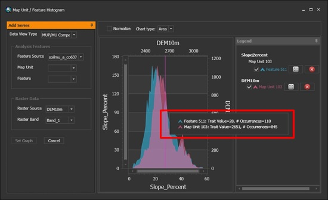

R GUI image

**Can I normalize the data ranges?**  
To normalize data so that the data ranges are comparable within the graph window, check the normalize button at the top of the graph.

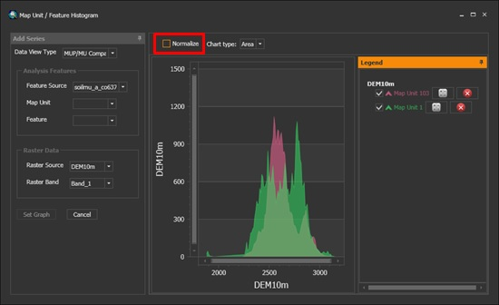

R GUI image

**How do I remove a graph series from the graph window?**  
Simply hit the red X next to the graph series you would like to remove in the graph legend.

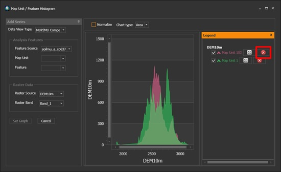

R GUI image

**How do I view the tabular data associated with each map unit or feature in the graph window?**  
To view the tabular and descriptive statistics of each map unit or feature in the graph window, simply select the table icon next to the data series in the graph legend.

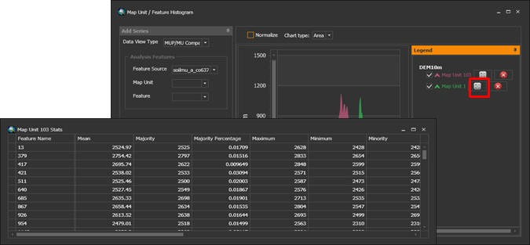

R GUI image

**SECTION 5. Exporting Statistics Data to Excel**

The statistical data summaries produced by the toolkit can be exported to excel as a .CSV file for further use.

**Export individual feature statistics**

1. On the main menu bar, click the **export table button** with the green arrow. Note this may take a little while as the program is gathering up the data.
2. Navigate to the location you would like to save the .CSV file. Give the file a name and click **Save**.

[figure not shown]

R GUI image

**Export map unit feature statistics**

1. On the main Toolkit menu bar, click the **export map unit table button** with the blue arrow. Note this may take a little while as the program is gathering up the data.
2. Navigate to the location you would like to save the .CSV file. Give the file a name and click **Save**.

# References

Vaughan, R., & Megown, K., 2015. The Terrestrial Ecological Unit Inventory (TEUI) Geospatial Toolkit: user guide v5.2. RSAC-10117-MAN1. Salt Lake City, UT: U.S. Department of Agriculture, Forest Service, Remote Sensing Applications Center. 40 p. http://www.fs.fed.us/eng/rsac/programs/teui/about.html